# Happy Moments

2024-01-28

Install packages

Install additional packages

Load packages

Read files

```
##    hmid  wid reflection_period
## 1 27673 2053               24h
## 2 27674    2               24h
## 3 27675 1936               24h
## 4 27676  206               24h
## 5 27677 6227               24h
## 6 27678   45               24h
##                                                                                                                          original_hm
## 1                                                      I went on a successful date with someone I felt sympathy and connection with.
## 2                                                                          I was happy when my son got 90% marks in his examination
## 3                                                                                       I went to the gym this morning and did yoga.
## 4 We had a serious talk with some friends of ours who have been flaky lately. They understood and we had a good evening hanging out.
## 5                                                             I went with grandchildren to butterfly display at Crohn Conservatory\n
## 6                                                                                                            I meditated last night.
##                                                                                                                           cleaned_hm
## 1                                                      I went on a successful date with someone I felt sympathy and connection with.
## 2                                                                          I was happy when my son got 90% marks in his examination
## 3                                                                                       I went to the gym this morning and did yoga.
## 4 We had a serious talk with some friends of ours who have been flaky lately. They understood and we had a good evening hanging out.
## 5                                                             I went with grandchildren to butterfly display at Crohn Conservatory\n
## 6                                                                                                            I meditated last night.
##   modified num_sentence ground_truth_category predicted_category
## 1     True            1                                affection
## 2     True            1                                affection
## 3     True            1                                 exercise
## 4     True            2               bonding            bonding
## 5     True            1                                affection
## 6     True            1               leisure            leisure
```

```
##   wid  age country gender marital parenthood
## 1   1 37.0     USA      m married          y
## 2   2 29.0     IND      m married          y
## 3   3   25     IND      m  single          n
## 4   4   32     USA      m married          y
## 5   5   29     USA      m married          y
## 6   6   35     IND      m married          y
```

```
##    hmid
## 1 27673
## 2 27674
## 3 27675
## 4 27676
## 5 27677
## 6 27678
##                                                                                                                                   hm
## 1                                                      I went on a successful date with someone I felt sympathy and connection with.
## 2                                                                          I was happy when my son got 90% marks in his examination
## 3                                                                                       I went to the gym this morning and did yoga.
## 4 We had a serious talk with some friends of ours who have been flaky lately. They understood and we had a good evening hanging out.
## 5                                                             I went with grandchildren to butterfly display at Crohn Conservatory\n
## 6                                                                                                            I meditated last night.
##   reflection  wid
## 1        24h 2053
## 2        24h    2
## 3        24h 1936
## 4        24h  206
## 5        24h 6227
## 6        24h   45
```

```
##    hmid tokenOffset   word lowercaseLemma  POS MWE offsetParent supersenseLabel
## 1 31526           1      I              i PRON   O            0
## 2 31526           2  found           find VERB   O            0     v.cognition
## 3 31526           3      a              a  DET   O            0
## 4 31526           4 silver         silver  ADJ   O            0
## 5 31526           5   coin           coin NOUN   O            0      n.artifact
## 6 31526           6   from           from  ADP   O            0
```

Missing Values

Data Exploration Differences in the types of exercise in happy moments between genders

Preliminary cleaning of text We clean the text by removing punctuation, numbers, empty words and extra white space.

```
## I went on a successful date with someone I felt sympathy and connection with
## I was happy when my son got marks in his examination
## I went to the gym this morning and did yoga
## We had a serious talk with some friends of ours who have been flaky lately They understood and we had a good evening hanging out
## I went with grandchildren to butterfly display at Crohn Conservatory
## I meditated last night
## I made a new recipe for peasant bread and it came out spectacular
## I got gift from my elder brother which was really surprising me
## YESTERDAY MY MOMS BIRTHDAY SO I ENJOYED
## Watching cupcake wars with my three teen children
```

Text Data Analysis 1.Stop Words and Word Cloud

[output not shown]

[output cut: 719 more lines]

[output not shown]

[output cut: 1633 more lines]

```
##                                                                                                                                         cleaned_hm
## 1                                                                       I went to the gym and really enjoyed how awesome my workout was afterwards
## 2                                                                                                                 I went for an early morning walk
## 3                                                                                                                 I took a pilates class at my gym
## 4                            I went mountain biking for the first time this year It was a short ride but it felt good to be back on the bike again
## 5              I was able to work together with my local Tema Instinct players to turn our part of town yellow and hold every gym for over a month
## 6                                                                                                                       I just finished my workout
## 7                                                                       I took a walk which even though I didn't want to made me feel better after
## 8                                                                                        I went for a run last night for the first time in a while
## 9                                                                        I went to the gym for the first time in a week which really made me happy
## 10 I got back to going to the gym for the first time last night It was hard but I'm really feeling it today so I know I'm back on track to fitness
##    predicted_category  age country gender marital
## 1            exercise   30     USA      o  single
## 2            exercise   30     USA      o married
## 3            exercise 31.0     USA      o  single
## 4            exercise   30     USA      o  single
## 5            exercise   23     USA      o  single
## 6            exercise   30     USA      o married
## 7            exercise   30     USA      o  single
## 8            exercise   30     USA      o  single
## 9            exercise 39.0     USA      o married
## 10           exercise 39.0     USA      o married
```

(1)Female

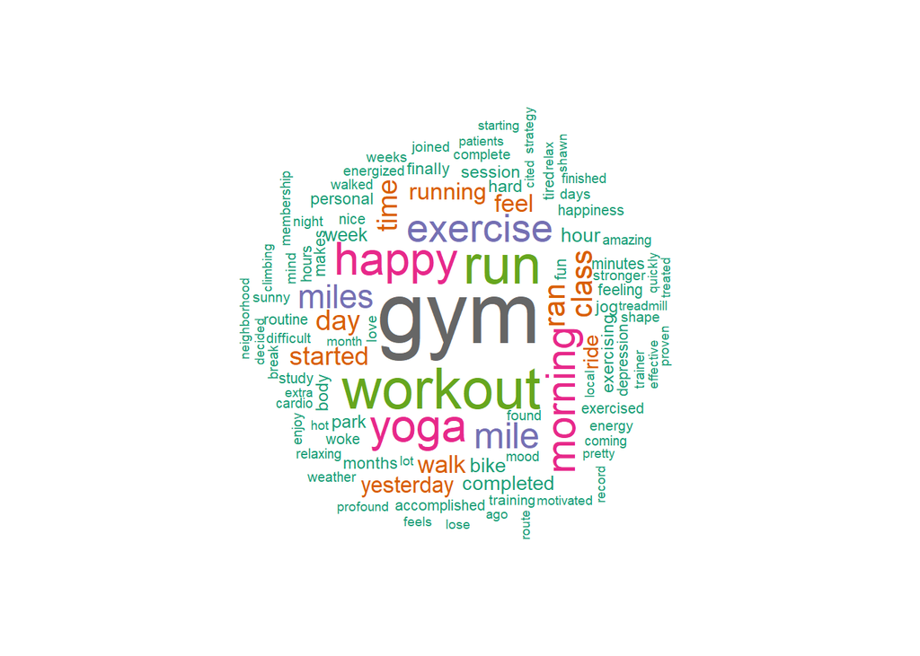

(2)Male

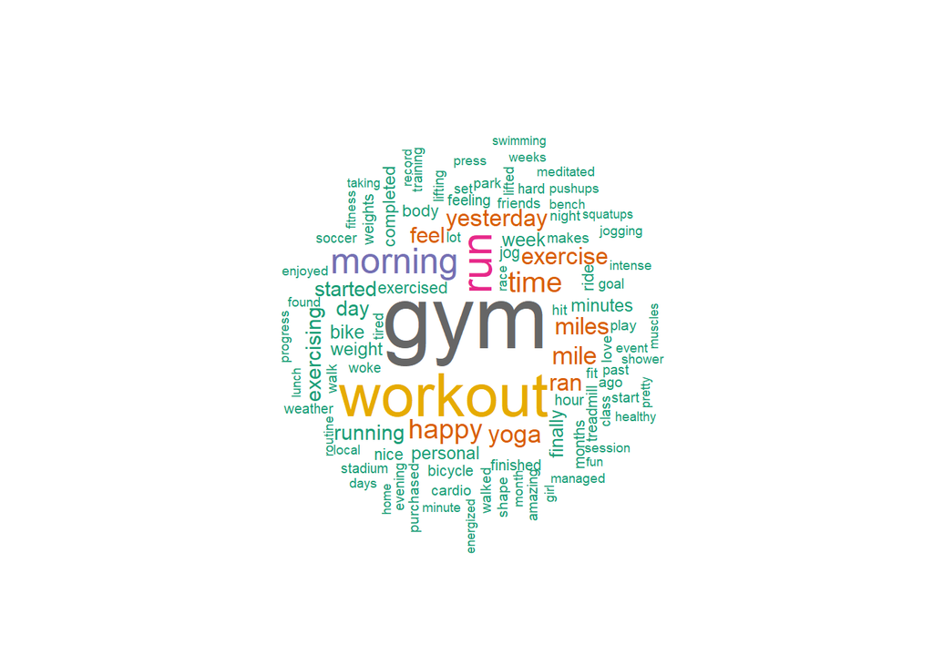

(3)Other

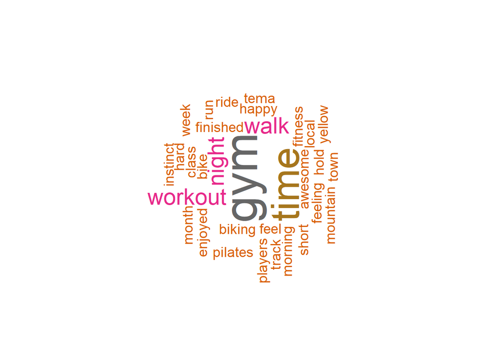

2. Frequency Words and Its Sentences (1)Female

```
## [1] "I went to the gym this morning and did yoga"
## [2] "I completed my miles run without break It makes me feel strong"
## [3] "Its the little things when I went to the gym today to do squats and other leg lifts the powercage was open all afternoon"
## [4] "I went for a long run on a trail near my house"
## [5] "I had a really tough workout in the morning and I managed to complete it while running incredibly quickly"
## [6] "Going to the gym during my lunch break made me happy"
```

Among the high-frequency words in our findings for moments that make women feel happy in their exercise are “gym”, “workout”, and “run”. We also matched the original sentences in which the words were found.

(2)Male

```
## [1] "Going for some running and exercising after three days break"
## [2] "After taking some off at the gymdue to illness I was able to wake up early and complete my normal squat workout at the same weight I had done prior to my break"
## [3] "I went to sports club and did running and exercise that's why I feel very fresh and happy"
## [4] "I run run run and run finally i catch a bus disappearing form my eyes Its make me feel nice"
## [5] "i have run for miles and the feeling is great"
## [6] "I went to my local gym to lift weight and do cardio The shower afterwards was refreshing"
```

Among the high-frequency words in our findings for moments that make men feel happy in their exercise are “gym”, “workout”, and “run”. We also matched the original sentences in which the words were found.

(3)Other

```
## [1] "I went to the gym and really enjoyed how awesome my workout was afterwards"
## [2] "I took a pilates class at my gym"
## [3] "I went mountain biking for the first time this year It was a short ride but it felt good to be back on the bike again"
## [4] "I was able to work together with my local Tema Instinct players to turn our part of town yellow and hold every gym for over a month"
## [5] "I went for a run last night for the first time in a while"
## [6] "I went to the gym for the first time in a week which really made me happy"
```

Among the high-frequency words in our findings for moments that make other feel happy in their exercise are “gym”, “night”, and “time”. We also matched the original sentences in which the words were found.

References

Asai, A., Evensen, S., Golshan, B., Halevy, A., Li, V., Lopatenko, A., Stepanov, D., Suhara, Y., Tan, W.-C., Xu, Y. (2018). “HappyDB: A Corpus of 100,000 Crowdsourced Happy Moments”, LREC ’18, May. (to appear)